# Solutions for 19/20: Sampling distributions, the CLT, and Bootstrapping

Notes and in-class exercises

# Warm-Up

Rivers contain small concentrations of mercury which can accumulate in fish. Scientists studied this phenomenon among largemouth bass in the Wacamaw and Lumber rivers of North Carolina.

One goal of this study was to explore the relationship of a fish’s mercury concentration (Concen) with its size, specifically its Length:

$$E(Concen | Length) = \beta_0 + \beta_1 Length$$

To this end, they caught and evaluated 171 fish, and recorded the following:

| variable | meaning |
| --- | --- |
| River | Lumber or Wacamaw |
| Station | Station number where the fish was caught (0, 1, …, 15) |
| Length | Fish’s length (in centimeters) |
| Weight | Fish’s weight (in grams) |
| Concen | Fish’s mercury concentration (in parts per million; ppm) |

```r
# Load the data & packages
library(tidyverse)
library(readr)
fish <- read_csv("https://Mac-STAT.github.io/data/Mercury.csv")
```

Plot and model the relationship of mercury concentration with length:

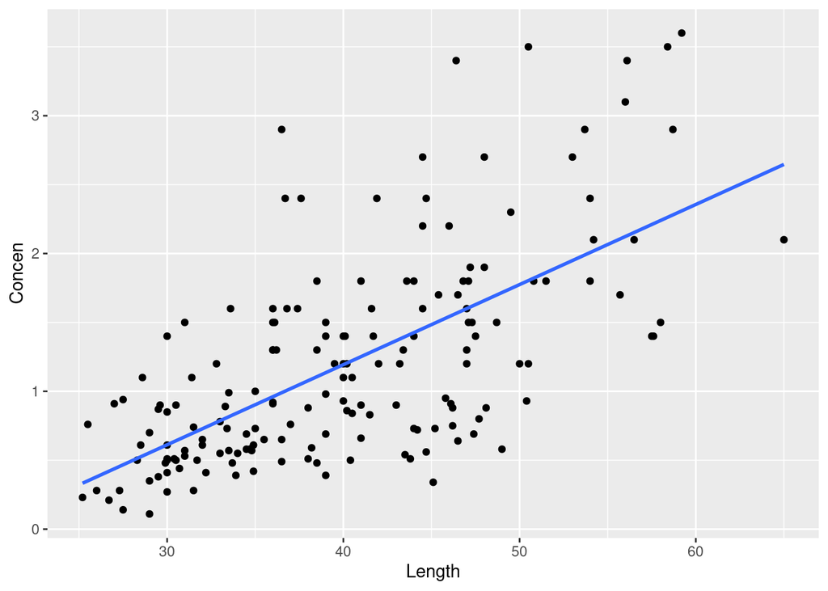

```r
fish %>%
  ggplot(aes(y = Concen, x = Length)) +
  geom_point() +
  geom_smooth(method = "lm", se = FALSE)
```

```r
fish_model <- lm(Concen ~ Length, data = fish)
coef(summary(fish_model))
```

```
               Estimate  Std. Error   t value     Pr(>|t|)
(Intercept) -1.13164542 0.213614796 -5.297598 3.617750e-07
Length       0.05812749 0.005227593 11.119359 6.641225e-22
```

## Exercise 1: 500 samples of size 10

1. `do()` repeats the code within the parentheses as many times as you tell it. do()` is a shortcut for a for loop.
2. 500 different sample estimates of the model

```r
# Set the seed so that we all get the same results
set.seed(155)

# Store the sample models
sample_models_10 <- mosaic::do(500)*(
  fish %>%
    sample_n(size = 10, replace = TRUE) %>%
    with(lm(Concen ~ Length))
)
# Check it out
head(sample_models_10)
```

```
   Intercept     Length     sigma r.squared          F numdf dendf .row .index
1 -2.7811151 0.09635286 0.5737186 0.7273700  21.343798     1     8    1      1
2 -3.0684939 0.10953496 0.3797853 0.9347767 114.655478     1     8    1      2
3 -1.2880671 0.05933243 0.7457468 0.3776855   4.855237     1     8    1      3
4 -0.9248832 0.05411299 0.6251621 0.4796674   7.374782     1     8    1      4
5 -1.0882523 0.05349699 0.3441272 0.4985134   7.952571     1     8    1      5
6 -0.4558309 0.04074788 0.7785389 0.1719987   1.661820     1     8    1      6
```

```r
dim(sample_models_10)
```

```
[1] 500   9
```

```r
# Set the seed so that we all get the same results
set.seed(155)

# Store the sample models
sample_models_boot <- mosaic::do(500)*(
  fish %>%
    sample_n(size = 171, replace = TRUE) %>%
    with(lm(Concen ~ Length))
)
```

## Exercise 2: Why “resampling” (`replace = TRUE`)?

```r
# Define data
small_sample <- data.frame(
  id = 1:5,
  Length = c(44, 43, 54, 52, 40))

small_sample
```

```
  id Length
1  1     44
2  2     43
3  3     54
4  4     52
5  5     40
```

1. The sample and the mean are the same every time!
2. If we rerun the code below multiple times, we’ll get different samples every time! Note that some of the observations are repeated (this is because of `replace = TRUE`), but we actually obtain variation in our samples and their mean lengths.

```r
sample_2 <- sample_n(small_sample, size = 5, replace = TRUE)
sample_2
```

```
  id Length
1  2     43
2  4     52
3  2     43
4  5     40
5  2     43
```

```r
sample_2 %>%
  summarize(mean(Length))
```

```
  mean(Length)
1         44.2
```

## Exercise 3: Sampling distribution

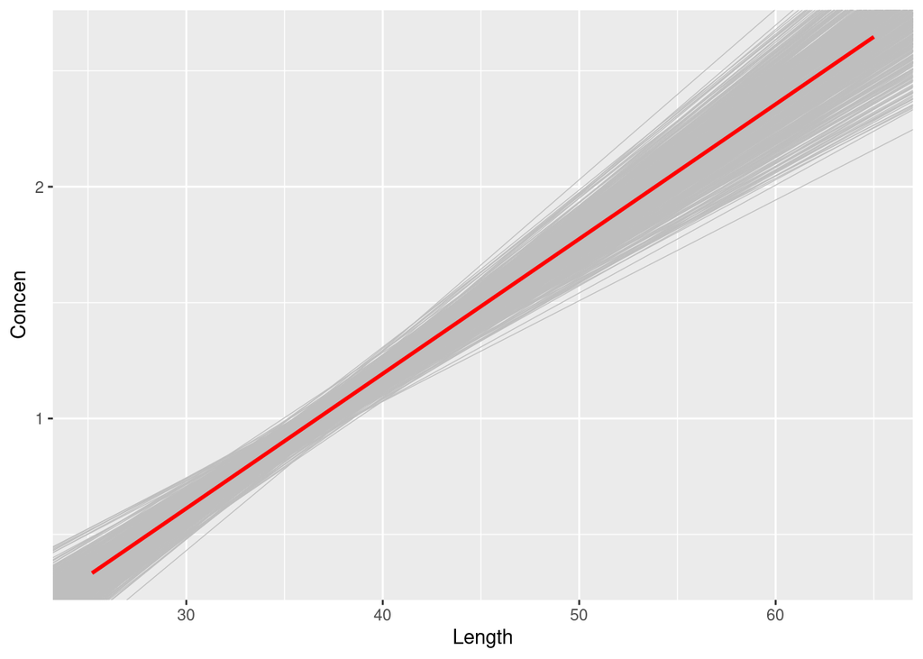

```r
fish %>%
  ggplot(aes(x = Length, y = Concen)) +
  geom_smooth(method = "lm", se = FALSE) +
  geom_abline(data = sample_models_boot,
              aes(intercept = Intercept, slope = Length),
              color = "gray", size = 0.25) +
  geom_smooth(method = "lm", color = "red", se = FALSE)
```

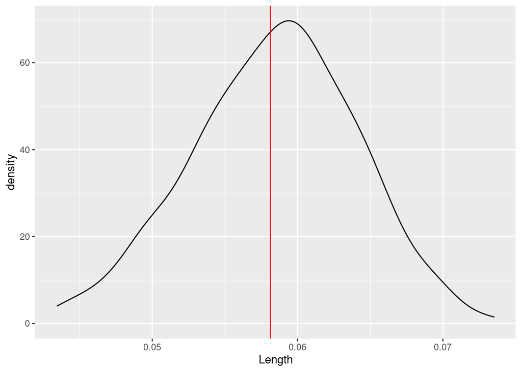

```r
sample_models_boot %>%
  ggplot(aes(x = Length)) +
  geom_density() +
  geom_vline(xintercept = 0.05813, color = "red")
```

1. The sampling distribution is symmetric, unimodal, and shaped like a bell curve!
2. It is roughly centered at the slope calculated from our entire sample!
3. Most of the estimates lie within the range 0.04 to 0.075.

## Exercise 4: Standard error

```r
# boostrapped se
sample_models_boot %>%
  summarize(sd(Length))
```

```
   sd(Length)
1 0.005664586
```

```r
# CLT se
coef(summary(fish_model))
```

```
               Estimate  Std. Error   t value     Pr(>|t|)
(Intercept) -1.13164542 0.213614796 -5.297598 3.617750e-07
Length       0.05812749 0.005227593 11.119359 6.641225e-22
```

They are basically identical! Both are about 0.005.

## Exercise 5: Central Limit Theorem (CLT)

Recall that the CLT assumes that, so long as our sample size is “big enough”, the sampling distribution of the sample slope will be Normal.

Specifically, all possible sample slopes will vary Normally around the population slope.

- Do your simulation results support this assumption? Why or why not?

> Yes! They support this assumption because the shape of sampling distribution is roughly normal (i.e. bell-shaped).

## Exercise 6: Using the CLT

```r
# Hint: Adapt the code from Exercise 4...
sample_models_10 %>%
  summarize(sd(Length))
```

```
  sd(Length)
1 0.02532877
```

1. 95%
2. 100% - 95% = 5%
3. (100 - 99.7)/2 = 0.15% (Note that we divide by two here, because we only want those *above* 3 SEs, not either above or below!)

## Exercise 7: CLT and the 68-95-99.7 Rule

- 68% of samples will produce $\hat{\beta}_1$ estimates within **1 st. err.** of $\beta_1$
- 95% of samples will produce $\hat{\beta}_1$ estimates within **2 st. err.** of $\beta_1$
- 99.7% of samples will produce $\hat{\beta}_1$ estimates within **3 st. err.** of $\beta_1$

## Exercise 8: Increasing sample size

Intuition, no wrong answer.

## Exercise 9: 500 samples of size n

```r
set.seed(155)
sample_models_50 <- mosaic::do(500)*(
  fish %>%
    sample_n(size = 50, replace = FALSE) %>%
    with(lm(Concen ~ Length))
)

# Check it out
head(sample_models_50)
```

```
  Intercept     Length     sigma r.squared        F numdf dendf .row .index
1 -1.310864 0.06393644 0.5646473 0.4846643 45.14316     1    48    1      1
2 -1.503983 0.06887405 0.6112830 0.5333146 54.85302     1    48    1      2
3 -1.730214 0.07140026 0.5940694 0.4561970 40.26725     1    48    1      3
4 -1.213346 0.05948225 0.5561451 0.4712989 42.78853     1    48    1      4
5 -1.221643 0.05925447 0.5471569 0.5190808 51.80887     1    48    1      5
6 -1.384057 0.06532957 0.5610290 0.5400105 56.35021     1    48    1      6
```

Similarly, take 500 samples of size 100, and build a sample model from each.

```r
set.seed(155)
sample_models_100 <- mosaic::do(500)*(
  fish %>%
    sample_n(size = 100, replace = FALSE) %>%
    with(lm(Concen ~ Length))
)

# Check it out
head(sample_models_100)
```

```
   Intercept     Length     sigma r.squared         F numdf dendf .row .index
1 -0.9745758 0.05400227 0.5965267 0.3361746  49.62917     1    98    1      1
2 -1.1187614 0.05655020 0.5864780 0.4173361  70.19301     1    98    1      2
3 -1.3507522 0.06512980 0.5629381 0.5332227 111.95023     1    98    1      3
4 -1.5201200 0.06712467 0.5220515 0.5113787 102.56432     1    98    1      4
5 -1.0181036 0.05525131 0.5746367 0.4031468  66.19447     1    98    1      5
6 -1.1369532 0.05868566 0.5773007 0.4378596  76.33367     1    98    1      6
```

## Exercise 10: Impact of sample size (part I)

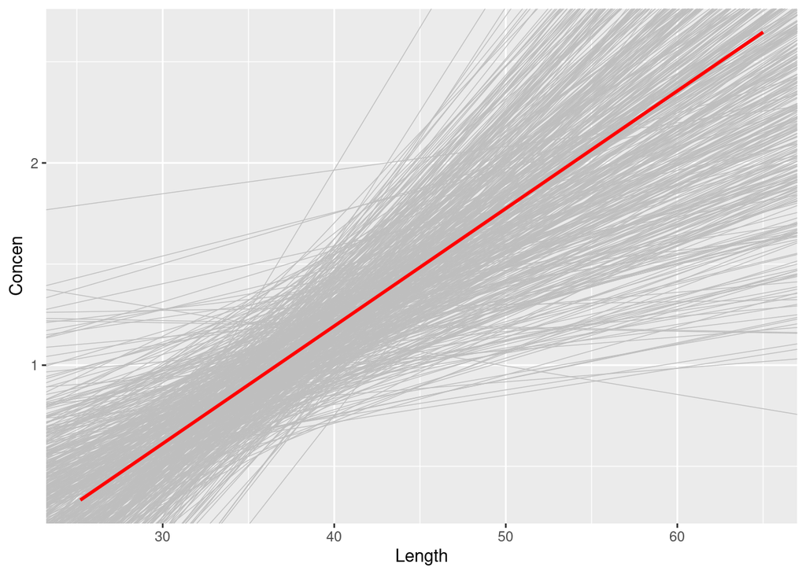

```r
# 500 sample models using samples of size 10
fish %>%
  ggplot(aes(x = Length, y = Concen)) +
  geom_smooth(method = "lm", se = FALSE) +
  geom_abline(data = sample_models_10,
              aes(intercept = Intercept, slope = Length),
              color = "gray", size = 0.25) +
  geom_smooth(method = "lm", color = "red", se = FALSE)
```

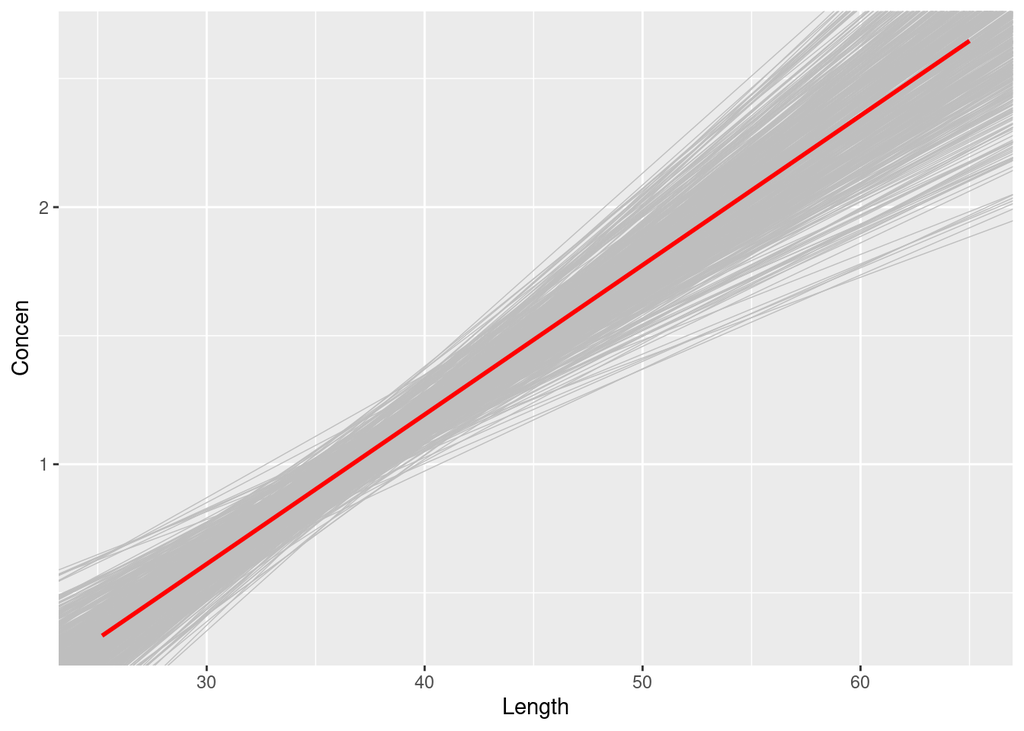

```r
# 500 sample models using samples of size 50
fish %>%
  ggplot(aes(x = Length, y = Concen)) +
  geom_smooth(method = "lm", se = FALSE) +
  geom_abline(data = sample_models_50,
              aes(intercept = Intercept, slope = Length),
              color = "gray", size = 0.25) +
  geom_smooth(method = "lm", color = "red", se = FALSE)
```

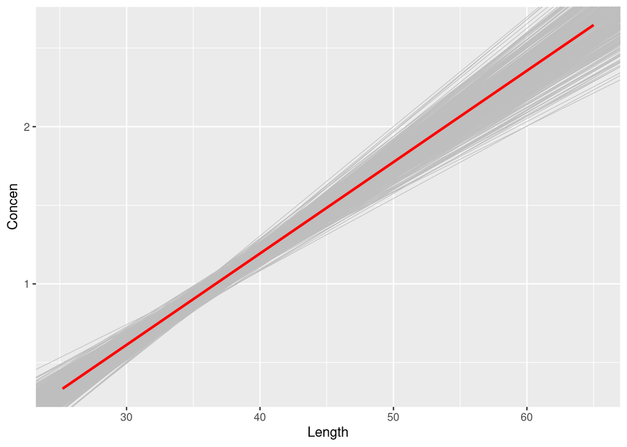

```r
# 500 sample models using samples of size 100
fish %>%
  ggplot(aes(x = Length, y = Concen)) +
  geom_smooth(method = "lm", se = FALSE) +
  geom_abline(data = sample_models_100,
              aes(intercept = Intercept, slope = Length),
              color = "gray", size = 0.25) +
  geom_smooth(method = "lm", color = "red", se = FALSE)
```

1. The sample model lines become less and less variable from sample to sample.

## Exercise 11: Impact of sample size (part II)

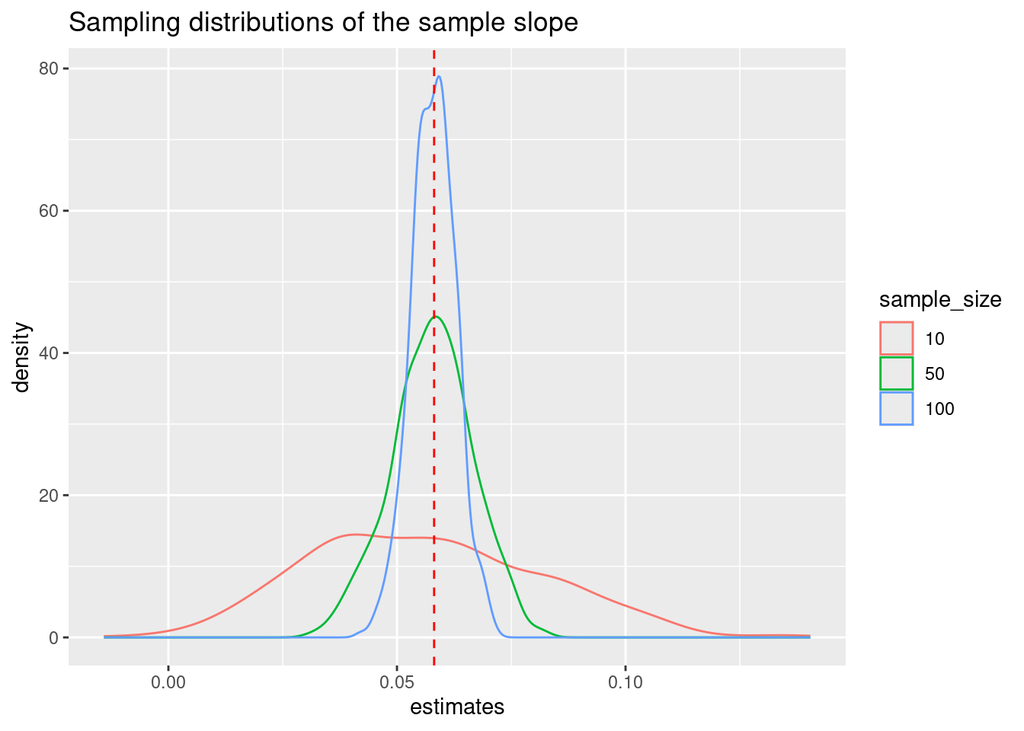

```r
# Don't think too hard about this code!
# Combine the estimates & sample size into a new data set
# Then plot it

data.frame(estimates = c(sample_models_10$Length, sample_models_50$Length, sample_models_100$Length),
           sample_size = rep(c("10","50","100"), each = 500)) %>%
  mutate(sample_size = fct_relevel(sample_size, c("10", "50", "100"))) %>%
  ggplot(aes(x = estimates, color = sample_size)) +
  geom_density() +
  geom_vline(xintercept = 0.05813, color = "red", linetype = "dashed") +
  labs(title = "Sampling distributions of the sample slope")
```

1. No matter the sample size, the sample estimates are normally distributed around the population slope. But as sample size increases, the variability of the sample estimates decreases.

## Exercise 12: Properties of sampling distributions

In light of your observations, complete the following statements about the sampling distribution of the sample slope.

1. For all sample sizes, the shape of the sampling distribution is roughly **normal** and the sampling distribution is roughly centered around **0.05813**, the sample estimate from our original data.
2. As sample size increases:  
   The average sample slope estimate IS FAIRLY STABLE.  
   The standard error of the sample slopes DECREASES.
3. Thus, as sample size increases, our sample slopes become MORE RELIABLE.